# DATA100 Group Project – 2020 Fall

Shengda Hu

02/11/2020

```r
writeLines("Team Name: Covid Combatters")
```

```
## Team Name: Covid Combatters
```

```r
tribble(
  ~"Last Name (Family)", ~"First Name (Given)", ~"Student ID",
  "Ashraf ", "Hafsah", 201911240,
  "Coonjobeeharry", "Rajveer", 170707330,
  "Lo", "Mariam", 200368340,
  "Palar", "Valencia Isabelle", 203302280,
  "Vangipuram", "Vivek", 200797670
)
```

```
## # A tibble: 5 x 3
##   `Last Name (Family)` `First Name (Given)` `Student ID`
##   <chr>                <chr>                       <dbl>
## 1 "Ashraf "            Hafsah                  201911240
## 2 "Coonjobeeharry"     Rajveer                 170707330
## 3 "Lo"                 Mariam                  200368340
## 4 "Palar"              Valencia Isabelle       203302280
## 5 "Vangipuram"         Vivek                   200797670
```

# Project introduction

Many things have happened and are happening in this year of 2020. The longest lasting, most widespread and probably defining event of the year so far – aside from what happens tomorrow – looks to be the COVID-19 pandemic. This project will ask you to use the methods and techniques we learned in DATA100 to get some understanding of this recent historical event.

Since many events are still unfolding and whatever data are out there are constantly being updated, revised, debated and reinterpreted, the understanding that will come out from this project will inevitably be incomplete at the best, probably inconclusive and plainly unreasonable at worst. So the main goal of the project is not to come up with the most reasonable or objective interpretations of the data or events involved, as what look reasonable now might become way off the mark as more information comes to light. The main goal of this project is to understand as much as possible what the stories the data sets available might tell. Put it in the cliched language: “let the data talk”, or in the more interesting phrase: “let the data ask questions”.

The theme of the story that we would like to understand is the following:

**What factors can be related to the level of observed infection / recovery / death by COVID-19 at a given time and given region**.

A most simple minded answer would be *everything*, because COVID-19 has definitely touched upon all facets of life. Through out this course, we are learning tools for “torturing the data until it confesses”, and the project is an attempt at teasing out some more detailed information. Note that the term **relationship** may be interpreted at least in the following three categories:

**1)** Causes higher / lower levels of COVID-19 infection / recovery / death

**2)** Caused by higher / lower levels of COVID-19 infection / recovery / death

**3)** Shows a correlation but causality unclear

There are more sophisticated methods that can provide more information to distinguish these three interpretations. For this project, it would be enough to give an intuitive interpretation in terms of one of these categories if you identified any relationship among the various factors. It is also completely reasonable that, from the data sets we have, it may appear that some factors do not correlate much to the COVID-19 – which is also knowledge gained.

In the following, besides the **3** online data sets on COVID-19, we provide **22** data sets concerning a number of potential factors of interest, such as *educational*, *political*, *economical*, *technological*, *employment*, *health*, *demographic*, *self perception* factors. As you can see, a number of them are not up-to-date, which is due to the availability of timely data – most of the interesting current data are not open data, or not easy to locate in more readily useful form to us. A number of COVID-19 related data sets are included, which by the collective work of many organizations, are updated real time. You are encouraged to track the most up-to-date version. We included the *WorldRegions.csv* data from World Regions Classification list on Wikipedia.

Also included are the data *WorldHappinessReport2020-Score.csv* from the World Happiness Report `2020`, which concerns the years `2017-2019`. It is computed based on the answers of people to the following question: “Please imagine a ladder, with steps numbered from 0 at the bottom to 10 at the top. The top of the ladder represents the best possible life for you and the bottom of the ladder represents the worst possible life for you. On which step of the ladder would you say you personally feel you stand at this time?” ([Statistical Appendix for Chapter 2](https://happiness-report.s3.amazonaws.com/2020/WHR20_Ch2_Statistical_Appendix.pdf) of [World Health Report 2020](https://worldhappiness.report/ed/2020/)) Thus, the score can be seen as giving one interpretation of happiness.

## The Map

The map below shows the `new cases` on Oct. 31, 2020 obtained from [Our world in data](https://covid.ourworldindata.org/data/ecdc/full_data.csv).

```r
COVID_cases <- read_csv("COVID-2020-10-31.csv",
                        col_types = cols(
                          location = col_character(),
                          new_cases = col_double(),
                          total_cases = col_double()
                        ))
COVID_cases
```

```
## # A tibble: 210 x 3
##    location            new_cases total_cases
##    <chr>                   <dbl>       <dbl>
##  1 Afghanistan               157       41425
##  2 Albania                   319       20634
##  3 Algeria                   319       57651
##  4 Andorra                    98        4665
##  5 Angola                    195       10269
##  6 Anguilla                    0           3
##  7 Antigua and Barbuda         3         127
##  8 Argentina               13955     1157166
##  9 Armenia                  2381       89813
## 10 Aruba                      17        4472
## # ... with 200 more rows
```

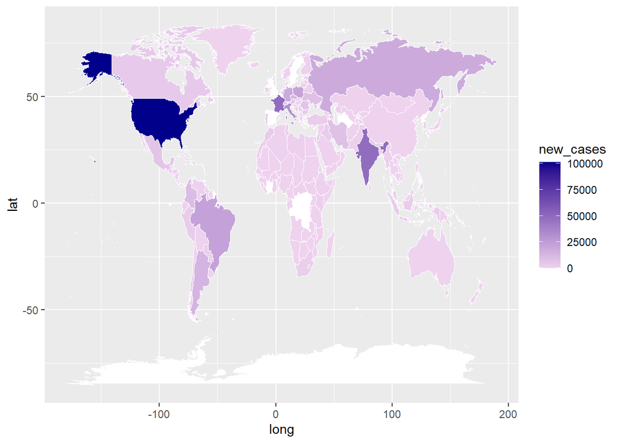

```r
world <- map_data("world")

iu <- COVID_cases %>% rename (region = location)

iu$region[198] <- "USA" # to match world map data

iu <- semi_join(iu, world, by = "region") #only keep countries according to world map data

# code below is modified from
# https://stackoverflow.com/questions/29614972/ggplot-us-state-map-colors-are-fine-polygons-jagged-r
gg <- ggplot()

gg <- gg + geom_map(
  data = world,
  map = world,
  aes(x = long, y = lat, map_id = region),
  fill = "#ffffff",
  color = "#ffffff",
  size = 0.20
  )
  gg <- gg + geom_map(
  data = iu,
  map = world,
  aes(fill = new_cases, map_id = region),
  color = "#ffffff",
  size = 0.15
  )

  gg <- gg + scale_fill_continuous(low = 'thistle2', high = 'darkblue',
  guide = 'colorbar')
  gg
```

# The Setup:

- Choose two dates to do your analysis, which have to be in different periods in the year 2020 as outlined below:
  - Before April 01
  - Between April 01 and September 01
  - After September 01
- From the **22** data sets provided below in the `.csv` files, select a subset (of at least `8`), covering at least `3` of the factors mentioned above. Describe how the data sets selected measure the factors chosen. I expect different groups would choose different subsets to work with.
- You need to include all **3** real-time online data sets, i.e. `COVID-19 cases`, `COVID-19 government responses` and `COVID-19 testing`. Besides the `8` data sets mentioned above, the real-time online data sets on `COVID-19 government responses` and `COVID-19 testing` must be included in your discussion.

# How the data sets selected measure the factors chosen: (Group Answer)

The data sets we selected are death, life expectancy, population, population distribution, unemployment rate, unemployed youth, labor force, GDP per capita, and expenditure. The unemployment rate, unemployed youth, expenditure, and GDP per capita all provide information about the employment factor during the time of COVID, which then also affects the economical factor. The death rate, life expectancy, and population count all provide information on the health and demographic factor of each country. The number of unemployed youth may also provide information to make conclusions about the education of a certain country.

# The Questions:

**Q: Provide a brief justification of the choice your group makes about the dates. `Random choice` is an acceptable justification.**

**Q: Form your own opinion concerning which factors are most likely to affect / be affected by the COVID-19 infection / recovery / death of a region, on the dates you selected. Note that most of the data sets are for years prior to `2020`.**

A:After discussing as a group, we concluded that in the time period we chose, the overall health and economy of every country was negatively affected the most. People were not as aware of the dangers of COVID and the importance of making efforts to prevent its spread at the time. During the peak of the COVID pandemic, the overall health of most countries depleted not only due to the drastic increase of COVID cases, but also because many people who needed treatment for diseases such as cancer, diabetes, etc., had not been receiving the medical attention they need to remain healthy. Health services in most countries had also been disrupted as many health workers at the time were reassigned to deal with severe COVID cases. The cancellation of planned treatment also terminated health services at the time.

**Q: Based on the interpretation of your group, analyze how the factors affect / are affected by the COVID-19 infection / recovery / death of a region, on the dates you selected, as represented by the real-time online data sets on `COVID-19 cases`.**

**Q: For the two chosen dates, for different regions, do you see the relationship you describe using the data sets change? What could be the potential reasons for such changes?**

# The Data sets

There are a total of **25** data sets, **3** of which are online real-time data sets that are regularly updated, while the remaining **22** can be obtained as `csv` files on MyLS. You may need to make the data tidy for some of them. Please note that the data sets are from different sources, you may need to first make sure, for example, the country / region names provided indeed do correspond.

The sources of the data are contained in the hyperlink. They are the following:

- CIA World FactBook: from which we obtained a majority of the data sets as `.csv` files
- World Bank Data: from which we obtained the data sets on Access to Electricity, Internet Usage, and Labor Force data
- Our World in Data: from which we obtain the online data sets on COVID-19 cases and testing
- [Economist Intelligence Unit](http://www.eiu.com/home.aspx): which developed the [democracy index](https://www.eiu.com/topic/democracy-index). The version we use is from the [Wikipedia page](https://en.wikipedia.org/wiki/Democracy_Index).
- University of Oxford: from which we obtain the online data set on Government Response
- United Nations: from which we obtained the data set on Population Distribution by Age and Gender
- Wikipedia: from which we obtained the World Regions Classification data set, aside from the democracy index above

### Real-time COVID-19 data sets:

These data are regularly updated, and they contain all the historical data, which include the periods that we are interested in. Once you choose and fixed the dates to work with, the updates should not affect your report.

[COVID-19 cases (Our world in data)](https://covid.ourworldindata.org/data/ecdc/full_data.csv)

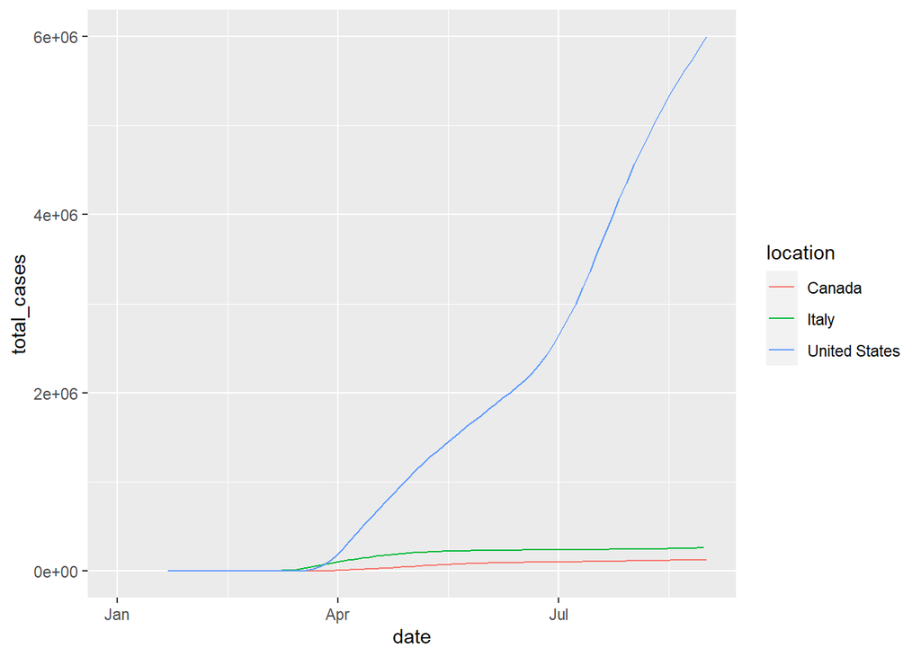

```r
covid_cases <- read_csv("https://covid.ourworldindata.org/data/ecdc/full_data.csv",
                        col_types = cols(
                          .default = col_double(),
                          date = col_date(format =""),
                          location = col_character()
                        ))%>%
  filter(between(date,as.Date("2020-01-01"),as.Date("2020-09-01")))

covid_cases_filtered<-covid_cases%>%
  filter(location == c("Canada", "United States", "Italy"))

covid_cases_filtered%>%
  ggplot()+ geom_line(mapping = aes(x = date, y = total_cases, color = location))
```

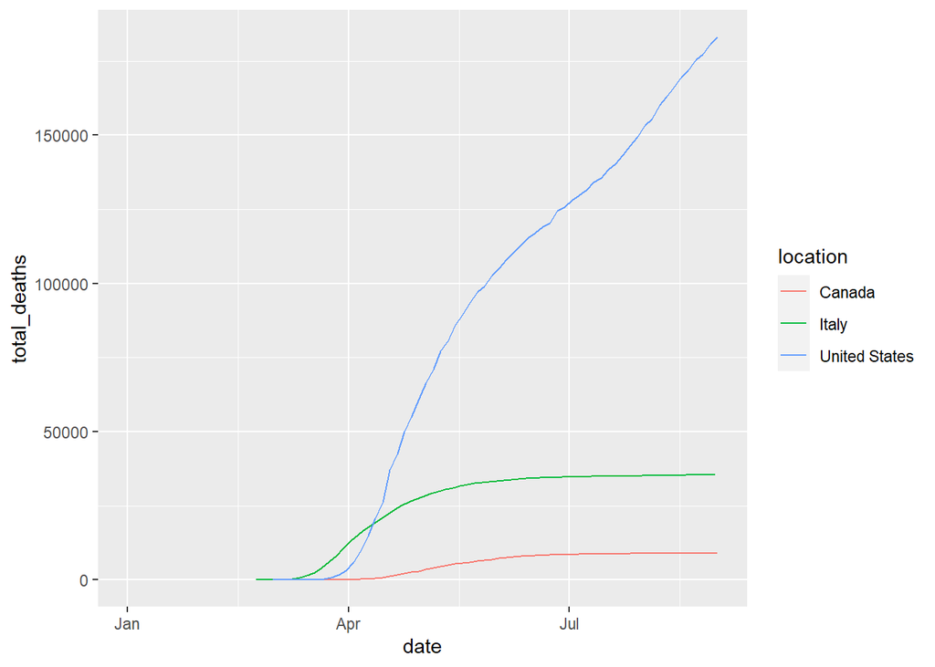

```r
covid_cases_filtered%>%
  ggplot()+ geom_line(mapping = aes(x = date, y = total_deaths, color = location))
```

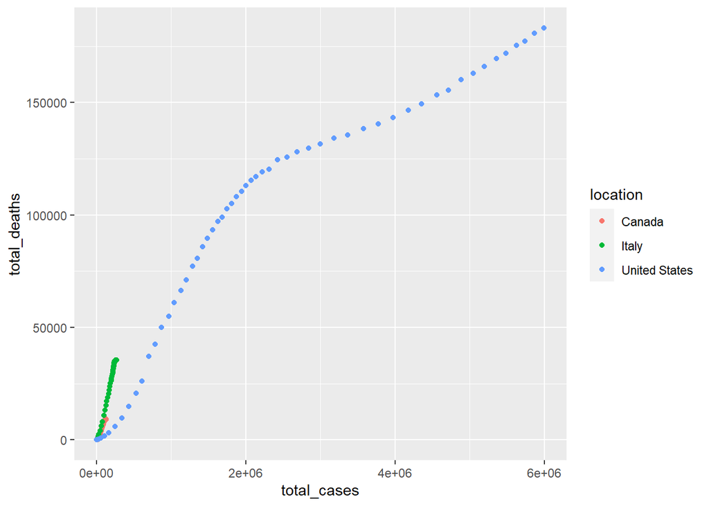

```r
covid_cases_filtered%>%
  ggplot() + geom_point(mapping = aes(x = total_cases, y = total_deaths, color = location))
```

```r
covid_cases_filtered
```

```
## # A tibble: 245 x 10
##    date       location new_cases new_deaths total_cases total_deaths
##    <date>     <chr>        <dbl>      <dbl>       <dbl>        <dbl>
##  1 2020-01-01 Canada           0          0          NA           NA
##  2 2020-01-04 Canada           0          0          NA           NA
##  3 2020-01-07 Canada           0          0          NA           NA
##  4 2020-01-10 Canada           0          0          NA           NA
##  5 2020-01-13 Canada           0          0          NA           NA
##  6 2020-01-16 Canada           0          0          NA           NA
##  7 2020-01-19 Canada           0          0          NA           NA
##  8 2020-01-22 Canada           0          0          NA           NA
##  9 2020-01-25 Canada           0          0          NA           NA
## 10 2020-01-28 Canada           1          0           2           NA
## # ... with 235 more rows, and 4 more variables: weekly_cases <dbl>,
## #   weekly_deaths <dbl>, biweekly_cases <dbl>, biweekly_deaths <dbl>
```

[COVID-19 testing (Our world in data)](https://covid.ourworldindata.org/data/testing/covid-testing-all-observations.csv)

```
Hasell, J., Mathieu, E., Beltekian, D. et al. A cross-country database of COVID-19 testing. Sci Data 7, 345 (2020). https://doi.org/10.1038/s41597-020-00688-8
```

```r
covid_tests <- read_csv("https://covid.ourworldindata.org/data/testing/covid-testing-all-observations.csv")
covid_tests_filtered <- covid_tests %>%
  filter(between(Date,as.Date("2020-01-01"),as.Date("2020-09-01"))) %>%
  filter(Entity == c("United States - tests performed", "Canada - people tested", "Italy - tests performed"))%>%
  select(-(`Source URL`:`Notes`))

covid_tests_filtered
```

```
## # A tibble: 184 x 11
##    Entity Date       `ISO code` `Cumulative tot~ `Daily change i~
##    <chr>  <date>     <chr>                 <dbl>            <dbl>
##  1 Canad~ 2020-03-13 CAN                      NA               NA
##  2 Canad~ 2020-03-16 CAN                   37730            12753
##  3 Canad~ 2020-03-19 CAN                   65851            12305
##  4 Canad~ 2020-03-22 CAN                   98824             9941
##  5 Canad~ 2020-03-25 CAN                  147789            22727
##  6 Canad~ 2020-03-28 CAN                  187448            16804
##  7 Canad~ 2020-03-31 CAN                  241138            15433
##  8 Canad~ 2020-04-03 CAN                  295065            21399
##  9 Canad~ 2020-04-06 CAN                  336806            12015
## 10 Canad~ 2020-04-09 CAN                  375302            13333
## # ... with 174 more rows, and 6 more variables: `Cumulative total per
## #   thousand` <dbl>, `Daily change in cumulative total per thousand` <dbl>,
## #   `7-day smoothed daily change` <dbl>, `7-day smoothed daily change per
## #   thousand` <dbl>, `Short-term tests per case` <dbl>, `Short-term positive
## #   rate` <dbl>
```

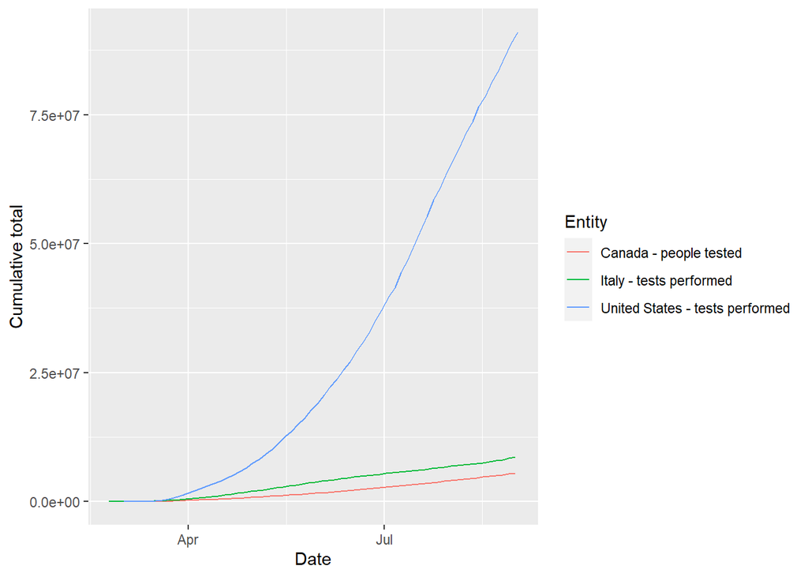

```r
covid_tests_filtered%>% ggplot(aes(x = Date, y = `Cumulative total`)) +
  geom_line(aes(color = Entity), se = TRUE)
```

[COVID-19 government responses](https://www.bsg.ox.ac.uk/research/research-projects/coronavirus-government-response-tracker#data)

```
University of Oxford, Blavatnik School of Government, "Coronavirus government response tracker"
```

You need to use the [codebook](https://github.com/OxCGRT/covid-policy-tracker/blob/master/documentation/codebook.md) to understand the meanings of the values

```r
covid_response <- read_csv("https://raw.githubusercontent.com/OxCGRT/covid-policy-tracker/master/data/OxCGRT_latest.csv",
                           col_types = cols(
                             .default = col_character(),
                             Date = col_date(format = "%Y%m%d"),
                             `E3_Fiscal measures` = col_double(),
                             `E4_International support` = col_double(),
                             `H4_Emergency investment in healthcare` = col_double(),
                             `H5_Investment in vaccines` = col_double(),
                             `C1_School closing` = col_double(),
                             `C2_Workplace closing` = col_double(),
                             `C4_Restrictions on gatherings` = col_double(),
                             `C1_Flag` = col_logical(),
                             `C2_Flag` = col_logical(),
                             `C3_Flag` = col_logical(),
                             `C4_Flag` = col_logical(),
                             `C5_Flag` = col_logical(),
                             `C6_Flag` = col_logical(),
                             `C7_Flag` = col_logical(),
                             `E1_Flag` = col_logical(),
                             `H1_Flag` = col_logical()
                           )) %>% filter(between(Date,as.Date("2020-01-01"),as.Date("2020-09-01")))

covid_response_gatherings_filtered <- covid_response %>%
  filter(CountryCode == c("CAN", "USA", "ITA"), `C1_School closing` >= 0, `C4_Restrictions on gatherings` >= 0)%>%
  select(`CountryName`:`Date`,`C4_Restrictions on gatherings`, -(`RegionName`:`RegionCode`))
```

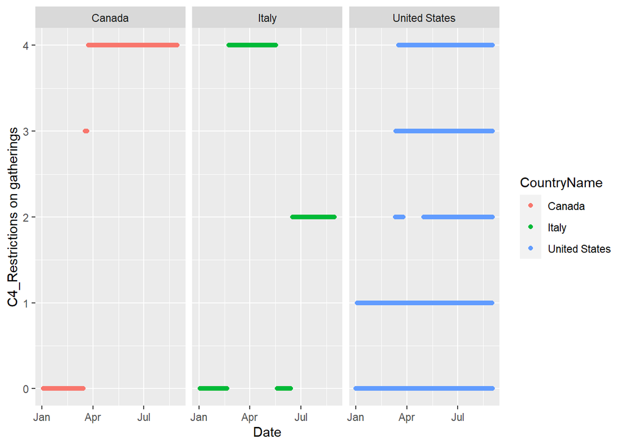

```r
covid_response_gatherings_filtered %>%
  ggplot(mapping = aes(x = Date, y = `C4_Restrictions on gatherings`, color = CountryName)) + geom_point()+facet_wrap(~CountryName)
```

```r
covid_response_workplace_restrictions <- covid_response %>%
  filter(CountryCode == c("CAN", "USA", "ITA"), `C2_Workplace closing`>=0)%>%
  select(`CountryName`:`Date`,`C2_Workplace closing`, -(`RegionName`:`RegionCode`))
```

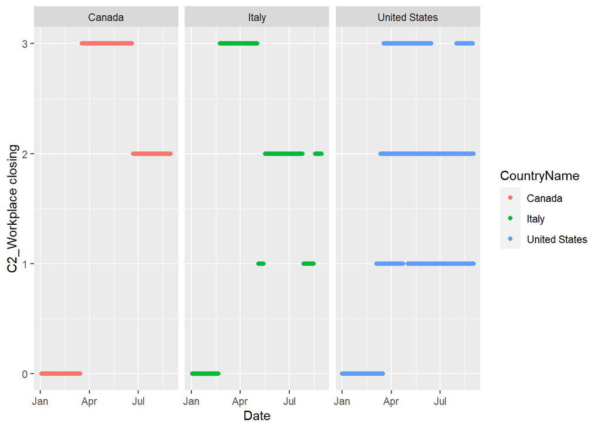

```r
covid_response_workplace_restrictions%>%
  ggplot(mapping = aes(x = Date, y = `C2_Workplace closing`, color = CountryName))+geom_point()+facet_wrap(~CountryName)
```

#### Datasets contained in `.csv` files

[democracy index](https://www.eiu.com/topic/democracy-index) developed by the [Economist Intelligence Unit](http://www.eiu.com/home.aspx), which is contained in the table from the [Wikipedia page](https://en.wikipedia.org/wiki/Democracy_Index).

```r
democracyindex <- read_tsv("DEMOCRACYINDEX.csv")
democracyindex %>% head()
```

```
## # A tibble: 6 x 12
##    Rank Country Score `Electoral proc~  `Functioning o~ `Political part~
##   <dbl> <chr>   <dbl>            <dbl>            <dbl>            <dbl>
## 1     1 Norway   9.87            10                9.64            10
## 2     2 Iceland  9.58            10                9.29             8.89
## 3     3 Sweden   9.39             9.58             9.64             8.33
## 4     4 New Ze~  9.26            10                9.29             8.89
## 5     5 Finland  9.25            10                8.93             8.89
## 6     6 Ireland  9.24            10                7.86             8.33
## # ... with 6 more variables: `Political culture` <dbl>, `Civil
## #   liberties` <dbl>, `Regime type` <chr>, Region <chr>, `Change from last
## #   year: Score` <chr>, `Change from last year: rank` <chr>
```

[World Regions Classification](https://meta.wikimedia.org/wiki/List_of_countries_by_regional_classification)

```r
regionclassification <- read_tsv("WorldRegions.csv")
regionclassification %>% head()
```

```
## # A tibble: 6 x 3
##   Country              Region              `Global South`
##   <chr>                <chr>               <chr>
## 1 Andorra              Europe              Global North
## 2 United Arab Emirates Arab States         Global South
## 3 Afghanistan          Asia & Pacific      Global South
## 4 Antigua and Barbuda  South/Latin America Global South
## 5 Anguilla             South/Latin America Global South
## 6 Albania              Europe              Global North
```

[World happiness report 2020, happiness score](https://worldhappiness.report/ed/2020/)

```r
happinessscore <- read_tsv("WorldHappinessReport2020-Score.csv")
happinessscore
```

```
## # A tibble: 153 x 3
##    Country     `Regional indicator`  `Ladder score`
##    <chr>       <chr>                          <dbl>
##  1 Finland     Western Europe                  7.81
##  2 Denmark     Western Europe                  7.65
##  3 Switzerland Western Europe                  7.56
##  4 Iceland     Western Europe                  7.50
##  5 Norway      Western Europe                  7.49
##  6 Netherlands Western Europe                  7.45
##  7 Sweden      Western Europe                  7.35
##  8 New Zealand North America and ANZ           7.30
##  9 Austria     Western Europe                  7.29
## 10 Luxembourg  Western Europe                  7.24
## # ... with 143 more rows
```

[Area of the regions](https://www.cia.gov/library/publications/resources/the-world-factbook/fields/279rank.html)

```r
area <- read_tsv("AREA.csv")
area
```

```
## # A tibble: 258 x 3
##     Rank Country       `(sq km)`
##    <dbl> <chr>             <dbl>
##  1     1 Russia         17098242
##  2     2 Antarctica     14200000
##  3     3 Canada          9984670
##  4     4 United States   9833517
##  5     5 China           9596960
##  6     6 Brazil          8515770
##  7     7 Australia       7741220
##  8     8 India           3287263
##  9     9 Argentina       2780400
## 10    10 Kazakhstan      2724900
## # ... with 248 more rows
```

[Population in the region](https://www.cia.gov/library/publications/resources/the-world-factbook/fields/335rank.html)

```r
population <- read_tsv("POPULATION.csv")
population
```

```
## # A tibble: 238 x 4
##     Rank Country       Population `Date of Information`
##    <dbl> <chr>              <dbl> <chr>
##  1     1 China         1394015977 July 2020 est.
##  2     2 India         1326093247 July 2020 est.
##  3     3 United States  332639102 July 2020 est.
##  4     4 Indonesia      267026366 July 2020 est.
##  5     5 Pakistan       233500636 July 2020 est.
##  6     6 Nigeria        214028302 July 2020 est.
##  7     7 Brazil         211715973 July 2020 est.
##  8     8 Bangladesh     162650853 July 2020 est.
##  9     9 Russia         141722205 July 2020 est.
## 10    10 Mexico         128649565 July 2020 est.
## # ... with 228 more rows
```

Population distribution The numeric values for the Pop columns are population in thousands.

```r
populationdistribution <- read_tsv("POPULATIONDISTRIBUTION.csv")
populationdistribution %>% head()
```

```
## # A tibble: 6 x 6
##   Location  Time   Age PopMale PopFemale PopTotal
##   <chr>    <dbl> <dbl>   <dbl>     <dbl>    <dbl>
## 1 Zimbabwe  2019     0    196.      193.     389.
## 2 Zimbabwe  2019     1    209.      206.     415.
## 3 Zimbabwe  2019     2    218.      215.     433.
## 4 Zimbabwe  2019     3    223.      221.     445.
## 5 Zimbabwe  2019     4    229.      227.     457.
## 6 Zimbabwe  2019     5    227.      226.     453.
```

[Life expectance at birth in the region](https://www.cia.gov/library/publications/resources/the-world-factbook/fields/355.html)

```r
lifeexpect <- read_tsv("LIFEEXPECTANCYATBIRTH.csv")%>%
  spread(key, value)%>%
  filter(!is.na(female))%>%
  separate(female, into=c("female", "delete1", "delete2"), sep = " ",convert=TRUE)%>%
  separate(male, into=c("male", "delete"), sep = " ",convert=TRUE)%>%
  separate(`total population`, into=c("total population", "delete3"), sep = " ",convert=TRUE) %>%
  select(-delete1,-delete2,-delete3, -delete)
lifeexpect
```

```
## # A tibble: 231 x 5
##    number female  male region              `total population`
##     <dbl>  <dbl> <dbl> <chr>                            <dbl>
##  1      1   54.4  51.4 Afghanistan                       52.8
##  2      2   81.9  76.3 Albania                           79
##  3      3   79.1  76.1 Algeria                           77.5
##  4      4   77.5  72.3 American Samoa                    74.8
##  5      5   85.4  80.8 Andorra                           83
##  6      6   63.4  59.3 Angola                            61.3
##  7      7   84.5  79.2 Anguilla                          81.8
##  8      8   79.6  75.1 Antigua and Barbuda               77.3
##  9      9   81.1  74.7 Argentina                         77.8
## 10     10   79.2  72.3 Armenia                           75.6
## # ... with 221 more rows
```

[Birthrate in the regions](https://www.cia.gov/library/publications/resources/the-world-factbook/fields/345rank.html)

```r
birthrate <- read_tsv("BIRTHRATE.csv")
birthrate %>% head()
```

```
## # A tibble: 6 x 4
##    Rank Country `(births/1,000 population)` `Date of Information`
##   <dbl> <chr>                         <dbl> <chr>
## 1     1 Niger                          47.5 2020 est.
## 2     2 Angola                         42.7 2020 est.
## 3     3 Uganda                         42.3 2020 est.
## 4     4 Mali                           42.2 2020 est.
## 5     5 Benin                          42.1 2020 est.
## 6     6 Chad                           41.7 2020 est.
```

[Deathrate in the region](https://www.cia.gov/library/publications/resources/the-world-factbook/fields/346rank.html)

```r
deathrate <- read_tsv("DEATHRATE.csv")
deathrate %>% head()
```

```
## # A tibble: 6 x 4
##    Rank Country   `(deaths/1,000 population)` `Date of Information`
##   <dbl> <chr>                           <dbl> <chr>
## 1     1 Lesotho                          15.4 2020 est.
## 2     2 Lithuania                        15   2020 est.
## 3     3 Bulgaria                         14.6 2020 est.
## 4     4 Latvia                           14.6 2020 est.
## 5     5 Ukraine                          14   2020 est.
## 6     6 Serbia                           13.5 2020 est.
```

[Labor force data in the region](https://data.worldbank.org/indicator/SL.TLF.TOTL.IN): the up-to-date data we use. [CIA](https://www.cia.gov/library/publications/resources/the-world-factbook/fields/218rank.html) has a slightly outdated data set.

```r
laborforce <- read_tsv("LABORFORCE.csv",
                       col_types = cols(
                         .default = col_double(),
                         `Country Name` = col_character(),
                         `Country Code` = col_character()
                       )) %>%
  gather(`1960`:`2020`, key = "years", value = "population")%>%
  filter(years >= 1990)
laborforce
```

```
## # A tibble: 8,184 x 4
##    `Country Name`       `Country Code` years population
##    <chr>                <chr>          <chr>      <dbl>
##  1 Aruba                ABW            1990          NA
##  2 Afghanistan          AFG            1990     3049464
##  3 Angola               AGO            1990     4844454
##  4 Albania              ALB            1990     1404177
##  5 Andorra              AND            1990          NA
##  6 Arab World           ARB            1990    61300691
##  7 United Arab Emirates ARE            1990      917445
##  8 Argentina            ARG            1990    13580769
##  9 Armenia              ARM            1990     1422950
## 10 American Samoa       ASM            1990          NA
## # ... with 8,174 more rows
```

[Unemployment in the region](https://www.cia.gov/library/publications/resources/the-world-factbook/fields/220rank.html)

```r
unemployment <- read_tsv("UNEMP.csv")
```

[figure not shown]

```r
unemployment %>%
  filter(Country == c("United States", "Canada")) %>%
  ggplot(mapping=aes(x=`Country`,y=Rank))+

  geom_boxplot(aes(color = Country, fill = Country), alpha = 0.5) +
  labs(title = "Unemployment in the region")
```

[Unemployment of youth in the region, ages 15-24](https://www.cia.gov/library/publications/resources/the-world-factbook/fields/373rank.html)

```r
unemp_youth <- read_tsv("UNEMPYOUTH.csv")
unemp_youth %>% head()
```

```
## # A tibble: 6 x 3
##    Rank Country          `(%)`
##   <dbl> <chr>            <dbl>
## 1     1 French Polynesia  56.7
## 2     2 South Africa      53.4
## 3     3 Kosovo            52.4
## 4     4 Libya             48.7
## 5     5 Eswatini          47.1
## 6     6 Gaza Strip        46.9
```

[Degree of urbanization in the region](https://www.cia.gov/library/publications/resources/the-world-factbook/fields/349.html)

```r
urbanization <- read_tsv("URBANIZATION.csv")
urbanization %>% head()
```

```
## # A tibble: 6 x 2
##   Region                      Afghanistan
##   <chr>                       <chr>
## 1 urban population            26% of total population
## 2 Data Year                   2020
## 3 annual rate of urbanization 3.37%
## 4 Rate est. period            2015-20
## 5 Region                      Albania
## 6 urban population            62.1% of total population
```

[School (primary to tertiary education) life expectancy in the region](https://www.cia.gov/library/publications/resources/the-world-factbook/fields/371.html)

```r
schooling <- read_tsv("SCHOOLINGEXPECTANCY.csv")
schooling %>% head()
```

```
## # A tibble: 6 x 3
##   key       value       number
##   <chr>     <chr>        <dbl>
## 1 Country   Afghanistan      1
## 2 total     10 years         1
## 3 male      13 years         1
## 4 female    8 years          1
## 5 data year 2018             1
## 6 Country   Albania          2
```

[Health expenditure in the region](https://www.cia.gov/library/publications/resources/the-world-factbook/fields/409.html)

```r
healthexp <- read_tsv("HEALTHEXP.csv")
healthexp %>% head()
```

```
## # A tibble: 6 x 3
##   Country             `Current Health Expenditure`  Year
##   <chr>               <chr>                        <dbl>
## 1 Afghanistan         10.3%                         2015
## 2 Albania             6.8%                          2015
## 3 Algeria             7.1%                          2015
## 4 Andorra             12%                           2015
## 5 Angola              2.9%                          2015
## 6 Antigua and Barbuda 4.8%                          2015
```

[Education expenditure in the region](https://www.cia.gov/library/publications/resources/the-world-factbook/rankorder/2206rank.html)

```r
educationexp <- read_tsv("EDUEXP.csv")
educationexp %>% head()
```

```
## # A tibble: 6 x 4
##    Rank Country               `(% OF GDP)` `Date of Information`
##   <dbl> <chr>                        <dbl>                 <dbl>
## 1     1 Lesotho                       13                    2008
## 2     2 Cuba                          12.8                  2010
## 3     3 Marshall Islands              12.2                  2003
## 4     4 Kiribati                      12                    2001
## 5     5 Botswana                       9.5                  2009
## 6     6 Sao Tome and Principe          9.5                  2010
```

[GDP per capital in the region](https://www.cia.gov/library/publications/resources/the-world-factbook/rankorder/2004rank.html)

```r
gdppp <- read_tsv("GDPPP.csv")
gdppp %>%
  arrange(desc("Date of Information"))
```

```
## # A tibble: 229 x 4
##     Rank Country       `GDP - PER CAPITA (PPP)` `Date of Information`
##    <dbl> <chr>         <chr>                    <chr>
##  1     1 Liechtenstein $139,100                 2009 est.
##  2     2 Qatar         $124,500                 2017 est.
##  3     3 Monaco        $115,700                 2015 est.
##  4     4 Macau         $111,600                 2017 est.
##  5     5 Luxembourg    $106,300                 2017 est.
##  6     6 Bermuda       $99,400                  2016 est.
##  7     7 Singapore     $93,900                  2017 est.
##  8     8 Isle of Man   $84,600                  2014 est.
##  9     9 Brunei        $78,200                  2017 est.
## 10    10 Ireland       $75,500                  2017 est.
## # ... with 219 more rows
```

[Public debt in the region](https://www.cia.gov/library/publications/resources/the-world-factbook/fields/227rank.html)

```r
publicdebt <- read_tsv("PUBLICDEBT.csv")
publicdebt %>% head()
```

```
## # A tibble: 6 x 4
##    Rank Country  `(% of GDP)` `Date of Information`
##   <dbl> <chr>           <dbl> <chr>
## 1     1 Japan            238. 2017 est.
## 2     2 Greece           182. 2017 est.
## 3     3 Barbados         157. 2017 est.
## 4     4 Lebanon          147. 2017 est.
## 5     5 Italy            132. 2017 est.
## 6     6 Eritrea          131. 2017 est.
```

[GDP composition by sector of origin in the region](https://www.cia.gov/library/publications/resources/the-world-factbook/fields/214.html)

```r
gdpcomp <- read_tsv("GDPCOMPOSITION.csv")
gdpcomp %>% head()
```

```
## # A tibble: 6 x 6
##   Country       algriculture industry services year     notes
##   <chr>         <chr>        <chr>    <chr>    <chr>    <chr>
## 1 Afghanistan   23%          21.1%    55.9%    2016 es~ data exclude opium prod~
## 2 Albania       21.7%        24.2%    54.1%    2017 es~ <NA>
## 3 Algeria       13.3%        39.3%    47.4%    2017 es~ <NA>
## 4 American Sam~ 27.4%        12.4%    60.2%    2012     <NA>
## 5 Andorra       11.9%        33.6%    54.5%    2015 es~ <NA>
## 6 Angola        10.2%        61.4%    28.4%    2011 es~ <NA>
```

[GINI index in the region](https://www.cia.gov/library/publications/resources/the-world-factbook/fields/223rank.html)

```r
gini <- read_tsv("GINI.csv")
gini %>% head()
```

```
## # A tibble: 6 x 4
##    Rank Country               `Distribution of family income~ `Date of Informat~
##   <dbl> <chr>                                           <dbl> <chr>
## 1     1 Lesotho                                          63.2 1995
## 2     2 South Africa                                     62.5 2013 est.
## 3     3 Micronesia, Federate~                            61.1 2013 est.
## 4     4 Haiti                                            60.8 2012
## 5     5 Botswana                                         60.5 2009
## 6     6 Namibia                                          59.7 2010
```

[Access to electricity (as percentage of population)](https://data.worldbank.org/indicator/EG.ELC.ACCS.ZS)

```r
accesstoelectricity <- read_tsv("ACCESSTOELECTRICITY.csv")
accesstoelectricity %>% head()
```

```
## # A tibble: 6 x 8
##   `Country Name` `Country Code` `2015` `2016` `2017` `2018` `2019` `2020`
##   <chr>          <chr>           <dbl>  <dbl>  <dbl>  <dbl> <lgl>  <lgl>
## 1 Aruba          ABW             100    100    100    100   NA     NA
## 2 Afghanistan    AFG              71.5   97.7   97.7   98.7 NA     NA
## 3 Angola         AGO              42     40.7   42.0   43.3 NA     NA
## 4 Albania        ALB             100    100    100    100   NA     NA
## 5 Andorra        AND             100    100    100    100   NA     NA
## 6 Arab World     ARB              88.7   89.3   90.3   89.3 NA     NA
```

[Individuals using the Internet (as percentage of population)](https://data.worldbank.org/indicator/IT.NET.USER.ZS)

```r
internetuser <- read_tsv("INTERNETUSER.csv")
internetuser %>% head()
```

```
## # A tibble: 6 x 8
##   Country     `Country Code` `2015` `2016` `2017` `2018` `2019` `2020`
##   <chr>       <chr>           <dbl>  <dbl>  <dbl>  <dbl>  <dbl> <lgl>
## 1 Aruba       ABW             88.7    93.5   97.2   NA     NA   NA
## 2 Afghanistan AFG              8.26   NA     11.4   NA     NA   NA
## 3 Angola      AGO             12.4    13     14.3   NA     NA   NA
## 4 Albania     ALB             63.3    66.4   71.8   NA     69.6 NA
## 5 Andorra     AND             96.9    97.9   91.6   NA     NA   NA
## 6 Arab World  ARB             43.7    41.5   50.0   63.2   NA   NA
```

Use the above data for your project. You do not need to look for extra data sets for this project. You may look at other data sets for ideas and inspirations, but in the analysis and report, only use the data sets provided above.

============================ Sanity check ============================

```r
democracyindex
```

```
## # A tibble: 167 x 12
##     Rank Country Score `Electoral proc~  `Functioning o~ `Political part~
##    <dbl> <chr>   <dbl>            <dbl>            <dbl>            <dbl>
##  1     1 Norway   9.87            10                9.64            10
##  2     2 Iceland  9.58            10                9.29             8.89
##  3     3 Sweden   9.39             9.58             9.64             8.33
##  4     4 New Ze~  9.26            10                9.29             8.89
##  5     5 Finland  9.25            10                8.93             8.89
##  6     6 Ireland  9.24            10                7.86             8.33
##  7     7 Denmark  9.22            10                9.29             8.33
##  8     7 Canada   9.22             9.58             9.64             7.78
##  9     9 Austra~  9.09            10                8.93             7.78
## 10    10 Switze~  9.03             9.58             9.29             7.78
## # ... with 157 more rows, and 6 more variables: `Political culture` <dbl>,
## #   `Civil liberties` <dbl>, `Regime type` <chr>, Region <chr>, `Change from
## #   last year: Score` <chr>, `Change from last year: rank` <chr>
```

```r
left_join(democracyindex, happinessscore, by = "Country")
```

```
## # A tibble: 167 x 14
##     Rank Country Score `Electoral proc~  `Functioning o~ `Political part~
##    <dbl> <chr>   <dbl>            <dbl>            <dbl>            <dbl>
##  1     1 Norway   9.87            10                9.64            10
##  2     2 Iceland  9.58            10                9.29             8.89
##  3     3 Sweden   9.39             9.58             9.64             8.33
##  4     4 New Ze~  9.26            10                9.29             8.89
##  5     5 Finland  9.25            10                8.93             8.89
##  6     6 Ireland  9.24            10                7.86             8.33
##  7     7 Denmark  9.22            10                9.29             8.33
##  8     7 Canada   9.22             9.58             9.64             7.78
##  9     9 Austra~  9.09            10                8.93             7.78
## 10    10 Switze~  9.03             9.58             9.29             7.78
## # ... with 157 more rows, and 8 more variables: `Political culture` <dbl>,
## #   `Civil liberties` <dbl>, `Regime type` <chr>, Region <chr>, `Change from
## #   last year: Score` <chr>, `Change from last year: rank` <chr>, `Regional
## #   indicator` <chr>, `Ladder score` <dbl>
```